# DATA 621 - Homework 1

Joshua Sturm

February 26, 2018

# Introduction

In this homework assignment, you will explore, analyze and model a data set containing approximately 2200 records. Each record represents a professional baseball team from the years 1871 to 2006 inclusive. Each record has the performance of the team for the given year, with all of the statistics adjusted to match the performance of a 162 game season. Your objective is to build a multiple linear regression model on the training data to predict the number of wins for the team.

# 1. Data Exploration

## 1.1 Load packages

## 1.2 Read in data

## 1.2.1 Create data dictionary

## 1.3 Basic variable statistics

The training data has 2276 cases, with 17 variables.

INDEX, as its name suggest, is simply an index, which we can remove.

TARGET_WINS is our response variable, leaving the remaining 15 variables as our predictors.

Right off the bat `:)`, we notice the data has some oddities. Some variables are relatively sparse, particularly BASERUN_CS and BATTING_HBP. The latter two have so many missing cases, 772 (34%) and 2085 (92%) respectively, that it would be unreasonable to include them for use in any meaningful statistical model, so they will require further examining in part 3.

## 1.4 Summary Graphs

### 1.4.1 Boxplot

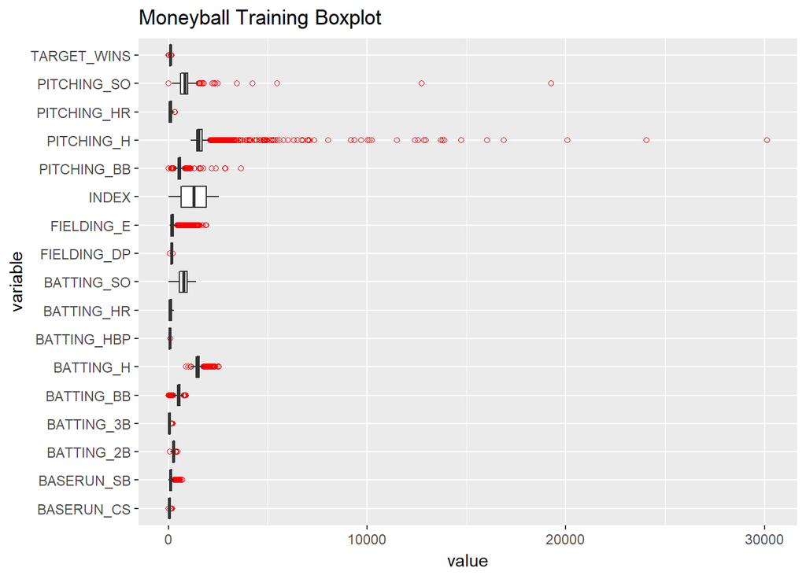

### 1.4.2 Histogram

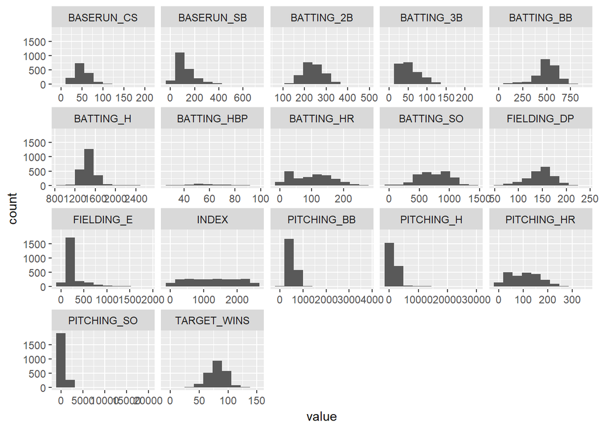

### 1.5 Correlation

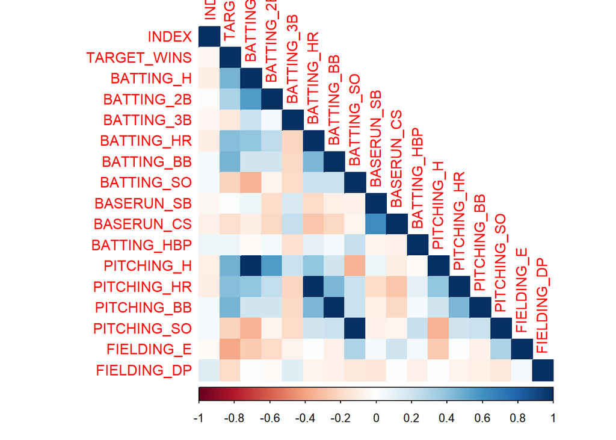

# 2. Data Preparation

## 2.1 Adding and removing variables

Another issue is the strong correlation between `PITCHING_HR` and `BATTING_HR` (97%!), which makes sense - they're essentially the same thing from opposite viewpoints. Since these variables are practically the same as each other, we can safely drop one of them.

As we mentioned in part 1, we're removing the two variables with a significant amount of missing data - `BATTING_HBP` and `BASERUN_CS`.

Additionally, FIELDING_DP is missing 12.5% of its total cases, so we will drop it. The remaining variables have less than 6% cases missing, so we'll attempt to model with those in place.

## 2.2 Missing data imputation

While we removed the variables that were missing a large portion of data, we're still left with others that have NA values.

BATTING_SO, BASERUN_SB, and PITCHING_SO have an average of ~ 112 missing cases.

After reading up on dealing with missing data in linear regression, it seems that imputation by means of regression is preferred over a basic statistical method such as mean, for example. To handle this, I'll make use of the `Hmisc` package.

## 2.3 Outliers

MLB statistics show the 1915 Philadelphia Athletics to have the most walks in a season, with 827. That works out to ~859 in a full 162-game season. Interestingly, removing the outliers for this variable actually makes the model *less* accurate; nevertheless, in the interest of staying consistent, I will discard any row with a value greater than 859.

Next is `PITCHING_H`. I couldn't find any data on most hits allowed, but according to [this list on wikipedia](https://en.wikipedia.org/wiki/List_of_Major_League_Baseball_hit_records), the most hits by a team in a season was 1,783, by the Phillies in 1930. This raises questions about the original dataset's max of `BATTING_H` of 2,554. If a team allowed 30,132 hits in a single season, that's an average of 186 hits per game...which is impossible. The record of 1,783 comes out to 11 hits per game. If they played a full 162-game season, it would come out to 1,874.

Since such a large portion of this variable is in outlier territory, it leads me to believe that it would be a mistake to discard the whole thing. However, I'm not exactly sure how to deal with it; statistical transformations, such as square root or log, have done little to rectify the issue. I will resort to removing the 320 rows with values larger than 1,874.

# 3. Build models

## 3.1 Model 1

I guess it makes the most sense to begin with a full model with all (non-transformed) variables included.

```
##
## Call:
## lm(formula = TARGET_WINS ~ ., data = mb.tr)
##
## Residuals:
##      Min       1Q   Median       3Q      Max
## -20.0626  -5.4196  -0.0423   5.2111  22.9355
##
## Coefficients:
##               Estimate Std. Error t value Pr(>|t|)
## (Intercept) 60.4562317 19.7385030   3.063  0.00254 **
## INDEX       -0.0002478  0.0008508  -0.291  0.77122
## BATTING_H    1.8111103  2.7908648   0.649  0.51723
## BATTING_2B   0.0267462  0.0303941   0.880  0.38008
## BATTING_3B  -0.1018043  0.0777401  -1.310  0.19208
## BATTING_HR  -4.6100155 10.5666083  -0.436  0.66317
## BATTING_BB  -4.4606275  3.6457882  -1.224  0.22279
## BATTING_SO   0.4303282  2.6231874   0.164  0.86988
## BASERUN_SB   0.0335937  0.0288100   1.166  0.24519
## BASERUN_CS  -0.0130338  0.0719436  -0.181  0.85645
## BATTING_HBP  0.0837038  0.0499097   1.677  0.09532 .
## PITCHING_H  -1.7887761  2.7903398  -0.641  0.52233
## PITCHING_HR  4.6958245 10.5649821   0.444  0.65725
## PITCHING_BB  4.5120283  3.6432611   1.238  0.21721
## PITCHING_SO -0.4618971  2.6214432  -0.176  0.86034
## FIELDING_E  -0.1724513  0.0415365  -4.152 5.16e-05 ***
## FIELDING_DP -0.1063200  0.0371964  -2.858  0.00478 **
## ---
## Signif. codes:  0 '***' 0.001 '**' 0.01 '*' 0.05 '.' 0.1 ' ' 1
##
## Residual standard error: 8.489 on 174 degrees of freedom
##   (2085 observations deleted due to missingness)
## Multiple R-squared:  0.5503, Adjusted R-squared:  0.509
## F-statistic: 13.31 on 16 and 174 DF,  p-value: < 2.2e-16
```

Not a very robust model; many insignificant variables, a low $R^2$ value, and a high AIC and BIC. There are also a lot of weird coefficients in this model. Triples, *home runs*, walks, (pitching) strikeouts, and double plays all have negative coefficients, meaning they are negatively correlated with the model.

## 3.2 Model 2

The second model I'll try contains the dataset with the added and removed variables, but none of them were transformed.

```
##
## Call:
## lm(formula = TARGET_WINS ~ ., data = mb2)
##
## Residuals:
##     Min      1Q  Median      3Q     Max
## -44.840  -7.961   0.168   7.573  50.911
##
## Coefficients:
##               Estimate Std. Error t value Pr(>|t|)
## (Intercept) 17.7010995  5.1280679   3.452 0.000568 ***
## BATTING_2B  -0.0081692  0.0071957  -1.135 0.256385
## BATTING_3B   0.1205824  0.0165717   7.276 4.87e-13 ***
## BATTING_HR   0.1201699  0.0083181  14.447  < 2e-16 ***
## BATTING_BB   0.0255959  0.0064707   3.956 7.90e-05 ***
## BATTING_SO  -0.0081180  0.0050803  -1.598 0.110213
## BASERUN_SB   0.0585237  0.0042963  13.622  < 2e-16 ***
## PITCHING_H   0.0024770  0.0004047   6.120 1.12e-09 ***
## PITCHING_BB -0.0027189  0.0051155  -0.531 0.595139
## PITCHING_SO -0.0040271  0.0044839  -0.898 0.369221
## FIELDING_E  -0.0499358  0.0032267 -15.476  < 2e-16 ***
## BATTING_1B   0.0396067  0.0037802  10.477  < 2e-16 ***
## ---
## Signif. codes:  0 '***' 0.001 '**' 0.01 '*' 0.05 '.' 0.1 ' ' 1
##
## Residual standard error: 11.63 on 2031 degrees of freedom
##   (233 observations deleted due to missingness)
## Multiple R-squared:  0.3611, Adjusted R-squared:  0.3577
## F-statistic: 104.4 on 11 and 2031 DF,  p-value: < 2.2e-16
```

This model has more sensible coefficients, even though it scored lower ($R^2$).

## 3.3 Model 3

The third model will be the modified dataset with all the transformed variables.

```
##
## Call:
## lm(formula = TARGET_WINS ~ ., data = mb3)
##
## Residuals:
##     Min      1Q  Median      3Q     Max
## -37.167  -7.689   0.164   7.561  39.790
##
## Coefficients:
##               Estimate Std. Error t value Pr(>|t|)
## (Intercept) 31.2810819  5.7031372   5.485 4.68e-08 ***
## BATTING_2B  -0.0830515  0.0192987  -4.303 1.77e-05 ***
## BATTING_3B   0.1469529  0.0241850   6.076 1.48e-09 ***
## BATTING_HR   0.0433160  0.0198254   2.185 0.029017 *
## BATTING_BB   0.1659864  0.0505731   3.282 0.001049 **
## BASERUN_SB   0.0882477  0.0048765  18.097  < 2e-16 ***
## PITCHING_H   0.0629874  0.0170545   3.693 0.000227 ***
## PITCHING_BB -0.1289791  0.0477955  -2.699 0.007024 **
## PITCHING_SO -0.0133305  0.0084776  -1.572 0.116014
## FIELDING_E  -0.0867680  0.0049191 -17.639  < 2e-16 ***
## BATTING_1B  -0.0368431  0.0183173  -2.011 0.044423 *
## BATTING_SO   0.0008721  0.0086850   0.100 0.920028
## ---
## Signif. codes:  0 '***' 0.001 '**' 0.01 '*' 0.05 '.' 0.1 ' ' 1
##
## Residual standard error: 11.12 on 1940 degrees of freedom
## Multiple R-squared:  0.3752, Adjusted R-squared:  0.3716
## F-statistic: 105.9 on 11 and 1940 DF,  p-value: < 2.2e-16
```

# 4. Model selection

To ensure uniformity between the datasets, I performed the same transformations on the evaluation set.

Here is a sample of the model's results:

```
## [1] "The mean error is: 1.50212479986918"
```

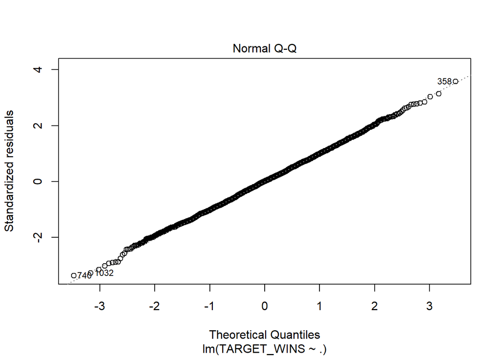

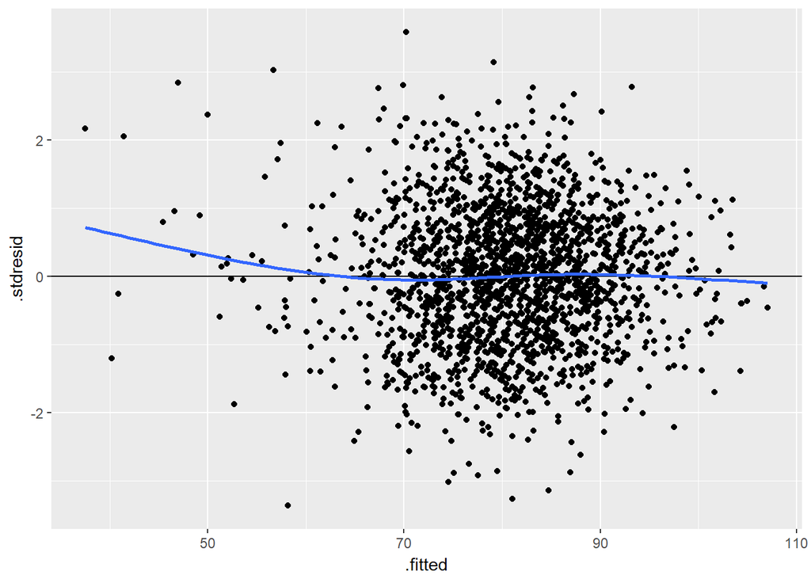

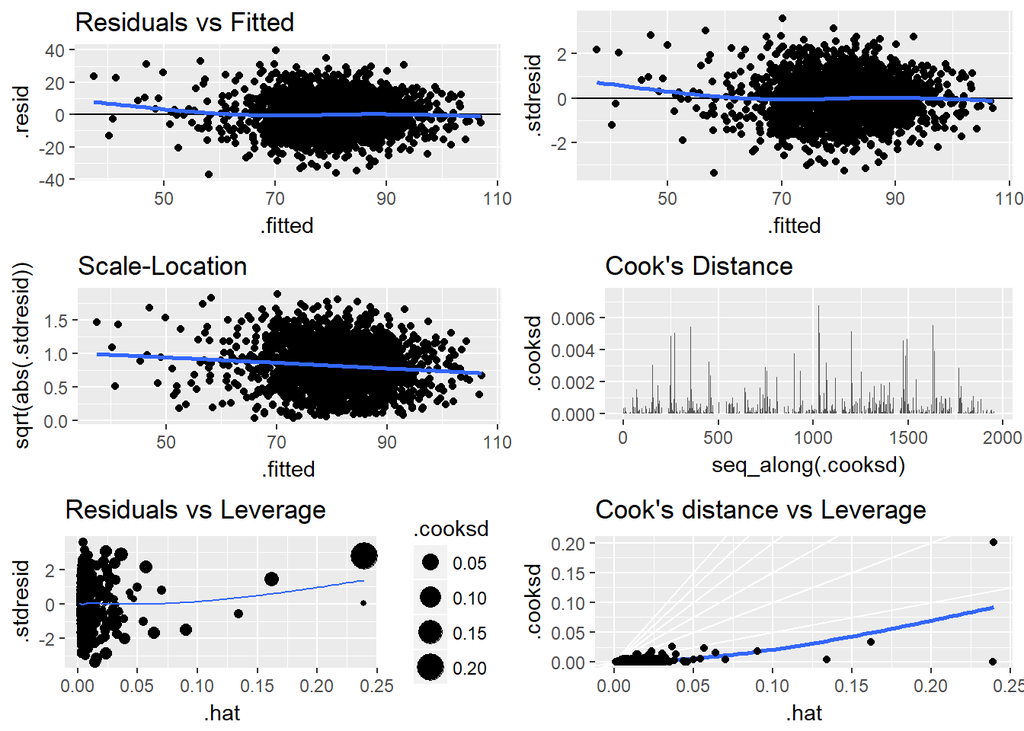

# 5. Closing words

I picked the third model, because I felt the data was the most honest - that is, it had the fewest outliers, and was closer to what it was meant to represent. The full model had a higher $R^2$, but that could be attributed to collinearity amongst the variables. The model is not perfect, and I likely would not use it in practice, but, given the many issues with the data, I believe I optimized it as best I could.

# References

- https://www.analyticsvidhya.com/blog/2016/03/tutorial-powerful-packages-imputing-missing-values/
- https://www.baseball-reference.com
- https://www.baseball-almanac.com
- https://www.mlb.com
- https://sports.stackexchange.com/questions/16246/what-is-the-mlb-record-for-most-errors-by-one-team-in-one-season-during-the-mode
- http://r-statistics.co/Linear-Regression.html
- http://ggplot2.tidyverse.org/reference/fortify.lm.html